# a6 API Report

Congressional Representatives

Bernabe Ibarra

2019-02-19

# Your Representative

This is a report about the political representatives based on the address entered (2681 NE University Village St Seattle, WA). This report draws upon data from the [ProPublica API](https://projects.propublica.org/api-docs/congress-api/) and the [Google Civic Data API](https://developers.google.com/civic-information/). As an overview, here is a summary of *who* represents the address given (from the **local** to the **national** level).

Name

Position

Party

email

Phone

Photo

Donald J. Trump

President of the United States

Republican Party

Not Available

202. 456-1111

https://www.whitehouse.gov/sites/whitehouse.gov/files/images/45/PE%20Color.jpg

Mike Pence

Vice-President of the United States

Republican Party

Not Available

202. 456-1111

https://www.whitehouse.gov/sites/whitehouse.gov/files/images/45/VPE%20Color.jpg

Maria Cantwell

United States Senate

Democratic Party

Not Available

202. 224-3441

http://bioguide.congress.gov/bioguide/photo/C/C000127.jpg

Patty Murray

United States Senate

Democratic Party

Not Available

202. 224-2621

http://bioguide.congress.gov/bioguide/photo/M/M001111.jpg

Pramila Jayapal

United States House of Representatives WA-07

Democratic Party

Not Available

202. 225-3106

NA

Jay Inslee

Governor

Democratic Party

Governor.JayInslee@governor.wa.gov

360. 902-4111

http://www.governor.wa.gov/sites/default/files/images/720px-for-web_0.jpg

Cyrus Habib

Lieutenant Governor

Democratic Party

ltgov@ltgov.wa.gov

360. 786-7700

http://www.ltgov.wa.gov/wp-content/uploads/2017/01/Senator-Habib-2015_CROPPED-225x300.jpg

Dow Constantine

County Executive

NA

kcexec@kingcounty.gov

206. 263-9600

http://www.kingcounty.gov/~/media/elected/portal/elected-exec-lg.ashx?la=en

Julie Wise

Elections Director

NA

elections@kingcounty.gov

206. 477-4140

NA

John Wilson

Assessor

NA

Not Available

206. 296-7300

NA

Dan Satterberg

Prosecuting Attorney

NA

Prosecuting.Attorney@kingcounty.gov

206. 477-1200

NA

Catherine Moore

King County Superior Court Judge

NA

moore.court@kingcounty.gov

206. 477-1591

NA

Mitzi Johanknecht

Sheriff

NA

sheriff@kingcounty.gov

206. 296-4155

NA

Teresa Mosqueda

Council, Position 8

Nonpartisan

teresa.mosqueda@seattle.gov

206. 684-8806

NA

Jenny Durkan

Mayor

Nonpartisan

jenny.durkan@seattle.gov

206. 684-4000

NA

Pete Holmes

Attorney

Nonpartisan

Peter.Holmes@seattle.gov

206. 684-8200

NA

M. Lorena González

Council, Position 9

Nonpartisan

Lorena.Gonzalez@seattle.gov

206. 684-8802

http://www.seattle.gov/Images/Council/Members/Gonzalez/gonzalez_thumb.jpg

Chris Reykdal

State Superintendent of Public Instruction

Nonpartisan

Not Available

360. 725-6115

NA

Bob Ferguson

Attorney General

Democratic Party

Not Available

360. 753-6200

NA

Pat McCarthy

State Auditor

Democratic Party

Not Available

360. 902-0370

NA

Hilary Franz

Commissioner of Public Lands

Democratic Party

Not Available

360. 902-1000

NA

Kim Wyman

Secretary of State

Republican Party

kim.wyman@sos.wa.gov

360. 902-4151

NA

Duane Davidson

State Treasurer

Republican Party

Not Available

360. 902-9001

NA

Mike Kreidler

Insurance Commissioner

Democratic Party

Not Available

360. 725-7000

NA

# House of Representatives

Now let’s take a look at all of the congressional representatives (in the House of Representatives, not the Senate) for the state in which the address was given. We see this breakdown by gender and political party for those members of the House:

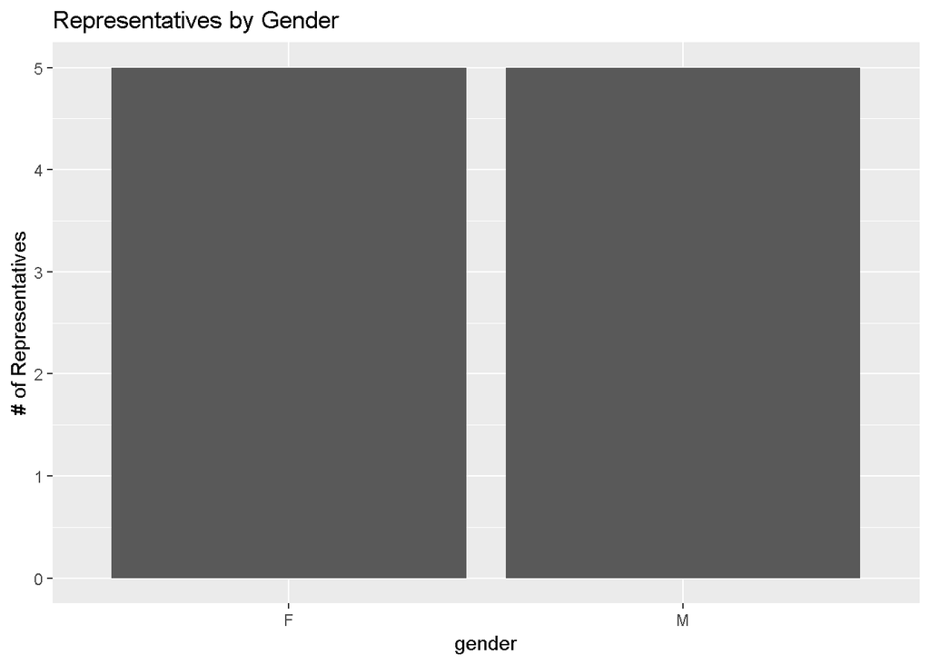

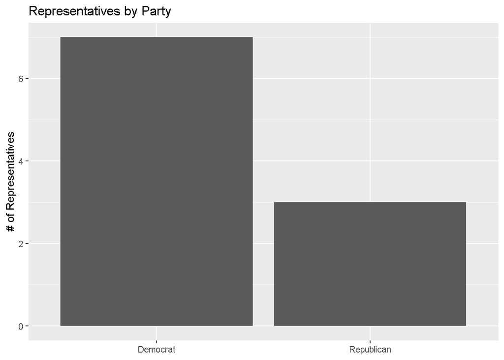

# Name